# Análise da precisão

```r
library(tidyverse)
library(here)
library(modelr)
library(broom)
library(dplyr)
theme_set(theme_bw())
```

## Os dados

```r
reclamacoes = read_csv(here("reclamacoes-avaliadas-20180703.csv"))
sentimentos = read_csv(here("sentimento.csv"))
reclamacoes = reclamacoes %>% mutate(comprimento_reclamacao = str_length(reclamacao))
```

```r
#inserindo colunas comprimento da reclamacao, do titulo e quantidade de exclamações
reclamacoes <- reclamacoes %>% mutate(reclamacao.length = str_length(reclamacao),
                                      titulo.length = str_length(titulo),
                                      numero.de.capslock = str_count(reclamacao,"[A-Z]"),
                                      reclamacao.qtdExclamacao = str_count(reclamacao, "[!]"),
                                      reclamacao.qtdNums = str_count(reclamacao,"[0-9]+"),
                                      reclamacao.qtdInterrogacao = str_count(reclamacao,"[?]"))
```

`reclamacoes_l` tem um formato long em vez de wide (explicado [aqui](https://sejdemyr.github.io/r-tutorials/basics/wide-and-long/)).

```r
reclamacoes = reclamacoes %>%
    left_join(sentimentos, by = "id")


reclamacoes_l = reclamacoes %>%
    select(-palavras_op30, -palavras_sent, -grupo_avaliando) %>%
    gather(key = "lexico",
           value = "polaridade",
           sentimento_op30, sentimento_sent)
reclamacoes_l %>% View()
```

```r
normalized_pol <- BBmisc::normalize(sentimentos$sentimento_op30, method= 'range', range = c(5,1))

#reclamacoes_l <-

# Faça você mesmo. Crie a variável polaridade_normalizada
 reclamacoes_l = reclamacoes_l %>%
     group_by(lexico) %>%
     mutate(polaridade_normalizada = normalized_pol)
```

Calcula o erro (SSE) por reclamação

```r
reclamacoes_l = reclamacoes_l %>%
    mutate(erro = (insatisfacao - normalizados)**2)
```

## EDA

Inicial. Faça os gráficos a mais que achar necessário para entender os dados que temos de resultado. Lembrando de nossa questão: Quão eficazes são os métodos de análise de sentimento baseados em léxicos para estimar o nível de insatisfação de reclamações recebidas pelo reclameaqui do governo federal? Existe um exemplo de EDA no repositório. Uma decisão importante a ser usada é se vamos considerar as avaliações humanas onde houve muita discordância sobre o nível de insatisfação.

###Como avaliar a eficácia dos métodos?  
Uma medida interessante da eficiência desses métodos é calcular a soma dos erros ao quadrado (SSE) considerando o que o método definiu como a polaridade_normalizada e o que a avaliação humana definiu como a insatisfação.

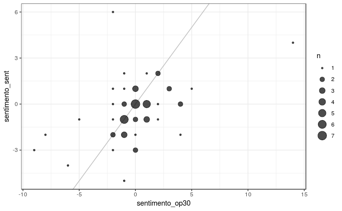

```r
reclamacoes %>%
    ggplot(aes(x = sentimento_op30, y = sentimento_sent)) +
    geom_abline(slope = 1, intercept = 0, color = "grey") +
    geom_count(alpha = .7)
```

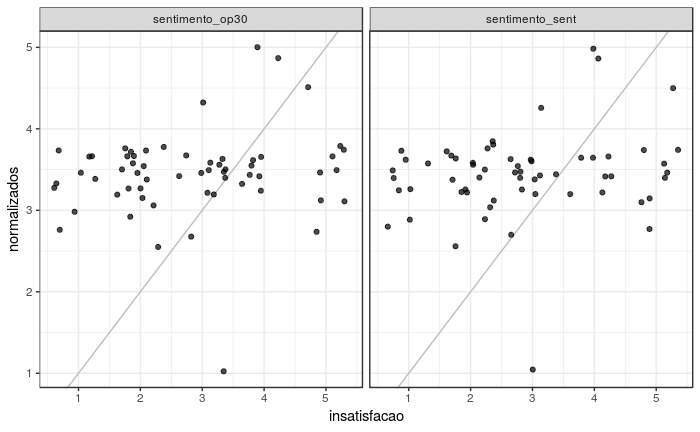

```r
reclamacoes_l %>%
    ggplot(aes(x = insatisfacao, y = normalizados, group = insatisfacao)) +
    geom_abline(slope = 1, intercept = 0, color = "grey") +
    geom_jitter(alpha = .7)  +
    facet_wrap(~ lexico)
```

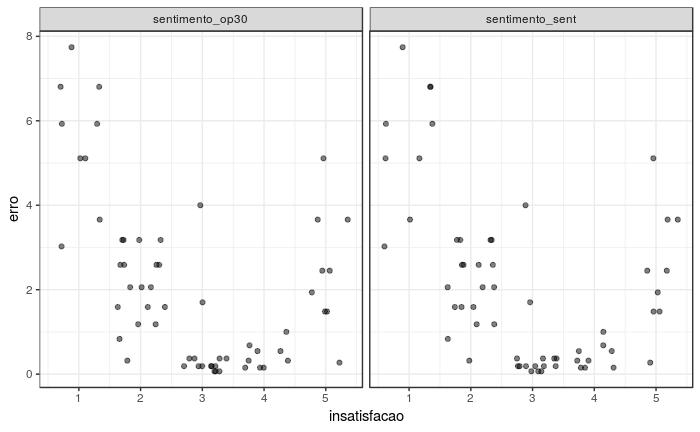

```r
reclamacoes_l %>%
    ggplot(aes(x = insatisfacao, y = erro, group = insatisfacao)) +
    geom_jitter(alpha = .5)  +
    #geom_boxplot() +
    facet_wrap(~ lexico)
```

Agora um modelo para responder sua pergunta.

```r
modelo1 = lm(insatisfacao ~ normalizados, data = reclamacoes_l)

tidy(modelo1, conf.int = TRUE, conf.level = 0.95)
```

| term | estimate | std.error | statistic | p.value | conf.low | conf.high |
| --- | --- | --- | --- | --- | --- | --- |
| (Intercept) | 1.5321318 | 0.7597076 | 2.016739 | 0.04599301 | 0.02770384 | 3.036560 |
| normalizados | 0.3830367 | 0.2182217 | 1.755264 | 0.08180934 | -0.04910167 | 0.815175 |

```r
glance(modelo1)
```

|  | r.squared | adj.r.squared | sigma | statistic | p.value | df | logLik | AIC | BIC | deviance | df.residual |
| --- | --- | --- | --- | --- | --- | --- | --- | --- | --- | --- | --- |
| 1 | 0.02544539 | 0.01718645 | 1.270028 | 3.080952 | 0.08180934 | 2 | -197.9488 | 401.8977 | 410.2602 | 190.3305 | 118 |

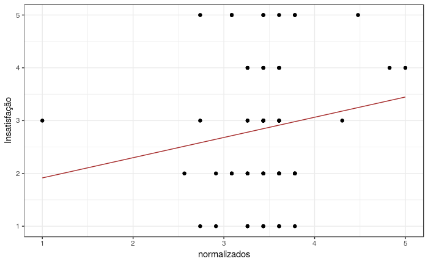

```r
reclamacoes_augmented = reclamacoes_l %>%
  add_predictions(modelo1)

reclamacoes_augmented %>%
  ggplot(aes(x = normalizados)) +
  geom_line(aes(y = pred), colour = "brown") +
  geom_point(aes(y = insatisfacao)) +
  labs(y = "Insatisfação")
```

[output not shown]

[output not shown]

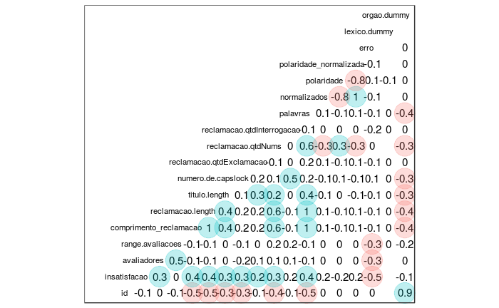

```r
#Cria variável dummy para preditor categórico
reclamacoes_l = reclamacoes_l %>% mutate(lexico.dummy = if_else(lexico == "sentimento_sent", 1, 0))
#Você precisa entender o que fez acima para interpretar sua regressão
#Você pode também criar uma variável dummy para o órgao (se anac ou inss)
reclamacoes_l = reclamacoes_l %>% mutate(orgao.dummy = if_else(orgao == "inss-ministerio-da-previdencia-social", 1, 0))

#GGally::ggpairs(reclamacoes_l %>% select(orgao.dummy, normalizados, erro, titulo.length, numero.de.capslock, comprimento_reclamacao, lexico.dummy))
ggcorr(data = reclamacoes_l, geom = "blank", label = "True", hjust = 0.90, size=3, layout.exp = 0.3) +
  geom_point(size = 10, aes(color = coefficient > 0, alpha = abs(coefficient) > 0.2)) +
  scale_alpha_manual(values = c("TRUE" = 0.25, "FALSE" = 0)) +
  guides(color = FALSE, alpha = FALSE)
```

```r
lm1 = lm(insatisfacao ~  numero.de.capslock+comprimento_reclamacao+titulo.length+erro+reclamacao.qtdExclamacao+polaridade_normalizada+reclamacao.qtdNums, data = reclamacoes_l)
tidy(lm1, conf.int = TRUE, conf.level = 0.95)
```

| term | estimate | std.error | statistic | p.value | conf.low | conf.high |
| --- | --- | --- | --- | --- | --- | --- |
| (Intercept) | 2.193029e-01 | 0.6901337937 | 0.3177687 | 7.512521e-01 | -1.1481087013 | 1.5867145933 |
| numero.de.capslock | 9.237825e-03 | 0.0018831853 | 4.9054252 | 3.184605e-06 | 0.0055065345 | 0.0129691152 |
| comprimento_reclamacao | -5.982354e-05 | 0.0001535914 | -0.3894980 | 6.976474e-01 | -0.0003641452 | 0.0002444981 |
| titulo.length | 1.147819e-02 | 0.0039369820 | 2.9154795 | 4.290361e-03 | 0.0036775651 | 0.0192788153 |
| erro | -2.940733e-01 | 0.0434405700 | -6.7695533 | 6.224519e-10 | -0.3801451745 | -0.2080013325 |
| reclamacao.qtdExclamacao | 3.806437e-02 | 0.0523284526 | 0.7274125 | 4.684912e-01 | -0.0656177514 | 0.1417464907 |
| polaridade_normalizada | 6.535929e-01 | 0.1817659320 | 3.5957945 | 4.824548e-04 | 0.2934470467 | 1.0137388358 |
| reclamacao.qtdNums | 5.792884e-02 | 0.0171839069 | 3.3711100 | 1.028105e-03 | 0.0238811313 | 0.0919765491 |

```r
glance(lm1)
```

|  | r.squared | adj.r.squared | sigma | statistic | p.value | df | logLik | AIC | BIC | deviance | df.residual |
| --- | --- | --- | --- | --- | --- | --- | --- | --- | --- | --- | --- |
| 1 | 0.5187289 | 0.4886494 | 0.9160876 | 17.24529 | 2.518522e-15 | 8 | -155.6159 | 329.2317 | 354.3191 | 93.99225 | 112 |